# Midterm Airline Analysis

##### b. Stacking Classifier

```python
from sklearn.linear_model import LogisticRegression
from sklearn.svm import SVC
from sklearn.ensemble import StackingClassifier
from xgboost import XGBClassifier
from sklearn.model_selection import KFold
from sklearn.model_selection import cross_validate
```

```python
def get_stacking():
    level0 = [
        ('lr', LogisticRegression(max_iter=1000, random_state=42)),
        ('xgb', XGBClassifier(eval_metric='logloss', random_state=42))
    ]
    level1 = LogisticRegression()

    stacking_model = StackingClassifier(
        estimators=level0,
        final_estimator=level1,
        cv=5,
        n_jobs=-1
    )
    return stacking_model
```

```python
def get_models(preprocessor):
    models = {
        'Logistic Regression': make_pipeline(preprocessor, LogisticRegression(max_iter=1000, random_state=42)),
        'XGBoost': make_pipeline(preprocessor, XGBClassifier(eval_metric='logloss', random_state=42)),
        'Stacking' : make_pipeline(preprocessor, get_stacking()),
    }
    return models
```

```python
def evaluate_model(model, X, y):
    cv = KFold(n_splits=3, shuffle=True, random_state=42)
    scoring = ['accuracy', 'f1', 'precision', 'recall']
    cv_results = cross_validate(model, X, y, cv=cv, scoring=scoring, n_jobs=-1, return_train_score=False)
    return {
        'accuracy': cv_results['test_accuracy'],
        'f1': cv_results['test_f1'],
        'precision': cv_results['test_precision'],
        'recall': cv_results['test_recall']
    }
```

```python
def compare_models(X_train, y_train, preprocessor):
    models = get_models(preprocessor)
    metrics = ['accuracy', 'precision', 'recall', 'f1']
    results = {metric: [] for metric in metrics}
    names = []

    for name, model in models.items():
        print(f"Evaluating: {name}")
        scores = evaluate_model(model, X_train, y_train)  # assumes evaluate_model returns means only

        names.append(name)
        for metric in metrics:
            results[metric].append(scores[metric].mean())

        print(f">{name:<18} | "
              f"Accuracy: {scores['accuracy'].mean():.3f} | "
              f"Precision: {scores['precision'].mean():.3f} | "
              f"Recall: {scores['recall'].mean():.3f} | "
              f"F1: {scores['f1'].mean():.3f}")

    # Create summary DataFrame
    summary_df = pd.DataFrame(results, index=names)
    print("\nModel Comparison Summary:")
    print(summary_df.round(3).sort_values('f1', ascending=False))

    # Bar plot for F1 scores
    plt.figure(figsize=(8, 4))
    plt.barh(summary_df.index, summary_df['f1'], color='skyblue')
    plt.xlabel("F1 Score")
    plt.title("Model Comparison (F1 Score)")
    plt.gca().invert_yaxis()
    plt.show()

    models = get_models(preprocessor_std)
    stacking_model = models['Stacking']
    stacking_model.fit(X_train, y_train)
    y_pred_stacking = stacking_model.predict(X_test)
     # Print classification report
    print("📊 Classification Report - Stacking:")
    print(classification_report(y_test, y_pred_stacking, target_names=le.classes_))
    cm_stacking = confusion_matrix(y_test, y_pred_stacking)
    disp_stacking = ConfusionMatrixDisplay(confusion_matrix=cm_stacking, display_labels=le.classes_)
    disp_stacking.plot(cmap='Blues')
    plt.title("Stacking Classifier Confusion Matrix")
    plt.show()
```

```
Evaluating: Logistic Regression
>Logistic Regression | Accuracy: 0.874 | Precision: 0.868 | Recall: 0.836 | F1: 0.852
Evaluating: XGBoost
>XGBoost            | Accuracy: 0.961 | Precision: 0.968 | Recall: 0.942 | F1: 0.955
Evaluating: Stacking
>Stacking           | Accuracy: 0.961 | Precision: 0.965 | Recall: 0.945 | F1: 0.955

Model Comparison Summary:
                     accuracy  precision  recall     f1
XGBoost                 0.961      0.968   0.942  0.955
Stacking                0.961      0.965   0.945  0.955
Logistic Regression     0.874      0.868   0.836  0.852
```

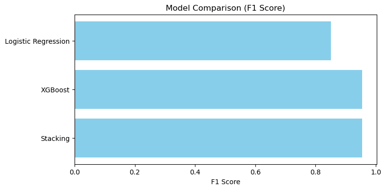

```
📊 Classification Report - Stacking:
                         precision    recall  f1-score   support

neutral or dissatisfied       0.96      0.97      0.97     22038
              satisfied       0.96      0.95      0.96     16926

               accuracy                           0.96     38964
              macro avg       0.96      0.96      0.96     38964
           weighted avg       0.96      0.96      0.96     38964
```

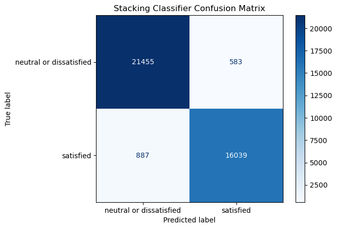

```python
compare_models(X_train, y_train, preprocessor_std)
```

**Stacking Model Summary**

- This stacking model consists of 2 base models: Logistic Regression, and XGBoost.
- The data itself contain revlevant information for perdiction, so even a basic logistic regression model can achieve a good performance.
- Precision is 0.96 and recall is 0.97 for class neutral and dissatisfied.
- Precision is 0.96 and recall is 0.95 for class satisfied.
- This model overall perform really well achieving a balance between precision and recall for both classes.